# Clase 3: Ejercicios

Luciano Catalán

2026-07-01

```r
library(tidyverse)
library(broom)
```

Trabajamos con los mismos datos de FRED de la clase. Asegúrate de que el archivo `datos/fred_macro.csv` esté en la misma carpeta que este `.Rmd`.

```r
macro <- read_csv("/Users/luxi/Desktop/ProgramacionParaEconomistas/Clase 3/datos/fred_macro.csv") %>% #Me estaba dando problemas leer el csv, lo tuve que copiar como path
  mutate(fecha = as.Date(fecha))


glimpse(macro)
```

```
## Rows: 294
## Columns: 4
## $ fecha        <date> 2000-01-01, 2000-02-01, 2000-03-01, 2000-04-01, 2000-05-…
## $ desempleo    <dbl> 4.6, 4.5, 4.6, 4.7, 4.5, 4.5, 4.8, 4.7, 4.5, 4.7, 4.6, 4.…
## $ inflacion    <dbl> 2.57, 2.39, 2.73, 2.64, 2.77, 2.76, 2.49, 2.57, 2.85, 2.8…
## $ tasa_interes <dbl> 5.68, 5.42, 5.43, 5.28, 5.29, 5.19, 5.18, 4.94, 4.89, 4.7…
```

# Parte 1 — Limpieza y preparación

**Ejercicio 1.** Verifica cuántos `NA` hay en cada columna.

```r
macro %>%
  summarise(across(everything(), ~ sum(is.na(.))))
```

```
## # A tibble: 1 × 4
##   fecha desempleo inflacion tasa_interes
##   <int>     <int>     <int>        <int>
## 1     0         0         0            0
```

**Ejercicio 2.** Crea las siguientes columnas nuevas en `macro` y guarda el resultado de vuelta en `macro`:

```r
macro <- macro %>%
  mutate(
    tasa_lag1 = lag(inflacion, 1),
    desempleo_lag1 = lag(desempleo, 1),
    recesion = desempleo > 7.5
  )

head(macro,10)
```

```
## # A tibble: 10 × 7
##    fecha      desempleo inflacion tasa_interes tasa_lag1 desempleo_lag1 recesion
##    <date>         <dbl>     <dbl>        <dbl>     <dbl>          <dbl> <lgl>
##  1 2000-01-01       4.6      2.57         5.68     NA              NA   FALSE
##  2 2000-02-01       4.5      2.39         5.42      2.57            4.6 FALSE
##  3 2000-03-01       4.6      2.73         5.43      2.39            4.5 FALSE
##  4 2000-04-01       4.7      2.64         5.28      2.73            4.6 FALSE
##  5 2000-05-01       4.5      2.77         5.29      2.64            4.7 FALSE
##  6 2000-06-01       4.5      2.76         5.19      2.77            4.5 FALSE
##  7 2000-07-01       4.8      2.49         5.18      2.76            4.5 FALSE
##  8 2000-08-01       4.7      2.57         4.94      2.49            4.8 FALSE
##  9 2000-09-01       4.5      2.85         4.89      2.57            4.7 FALSE
## 10 2000-10-01       4.7      2.85         4.74      2.85            4.5 FALSE
```

**Ejercicio 3.** Filtra solo las filas del período 2008–2012 y guárdalas en un objeto llamado `crisis_financiera`. ¿Cuántas observaciones tiene?

```r
crisis_financiera <- macro %>%
  filter(fecha >= "2008-01-01" & fecha <= "2012-12-31")

nrow(crisis_financiera)
```

```
## [1] 60
```

# Parte 2 — Exploración visual

**Ejercicio 4.** Grafica las tres series (`desempleo`, `inflacion`, `tasa_interes`) en paneles separados usando `facet_wrap`. Los datos deben estar en formato largo antes de graficar.

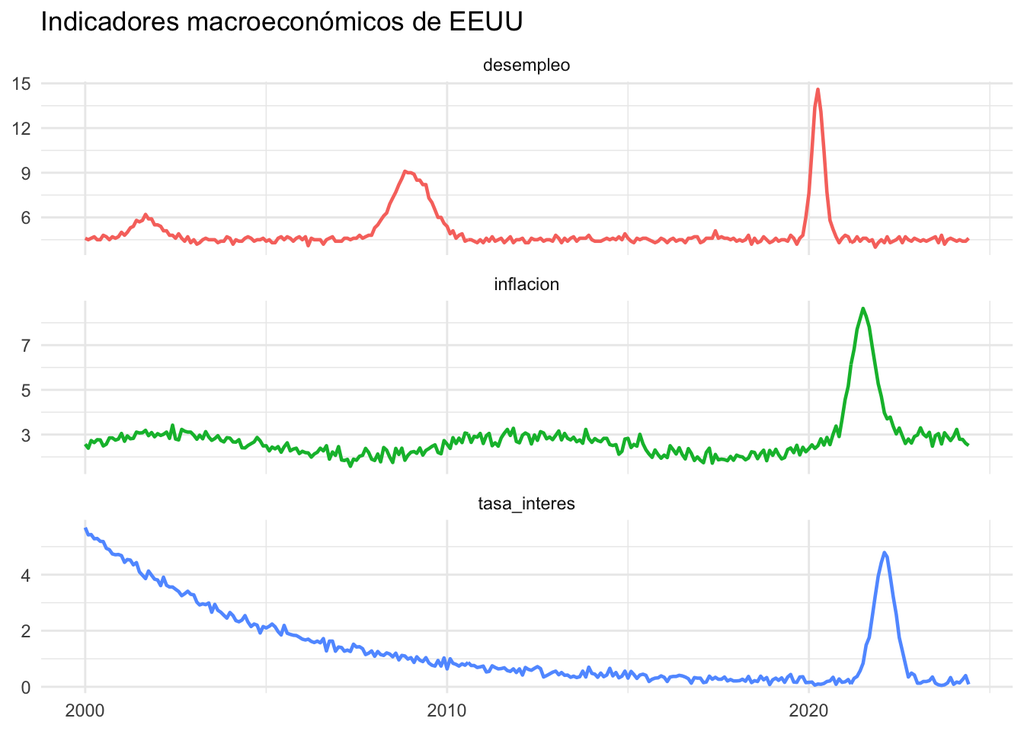

```r
macro %>%
  select(fecha, desempleo, inflacion, tasa_interes) %>%
  pivot_longer(-fecha, names_to = "serie", values_to = "valor") %>%
  ggplot(aes(x = fecha, y = valor, color = serie)) +
  geom_line(linewidth = 0.8) +
  facet_wrap(~ serie, scales = "free_y", ncol = 1) +
  labs(title = "Indicadores macroeconómicos de EEUU",
       x = NULL, y = NULL) +
  theme_minimal() +
  theme(legend.position = "none")
```

**Ejercicio 5.** Haz un gráfico de dispersión de `desempleo` (eje x) vs `tasa_interes` (eje y). Colorea los puntos por `crisis` y agrega una línea de regresión con `geom_smooth(method = "lm")`.

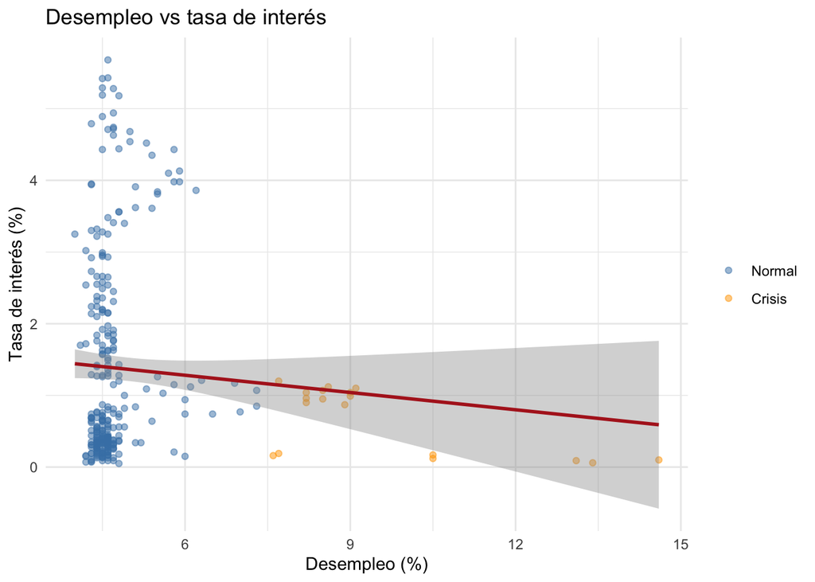

```r
macro %>%
  ggplot(aes(x = desempleo, y = tasa_interes)) +
  geom_point(aes(color = recesion), alpha = 0.5) +
  geom_smooth(method = "lm", se = TRUE, color = "firebrick") +
  scale_color_manual(values = c("FALSE" = "steelblue", "TRUE" = "orange"),
                     labels = c("Normal", "Crisis")) +
  labs(title = "Desempleo vs tasa de interés",
       x = "Desempleo (%)", y = "Tasa de interés (%)",
       color = NULL) +
  theme_minimal()
```

¿Qué relación observas entre desempleo y tasa de interés? ¿Tiene sentido económicamente?

*Tu interpretación aquí.*

Hay una relación negativa. Cuando el desempleo sube, la tasa de interés tiende a bajar. La línea de regresión cae y los puntos de crisis, con desempleo alto, se agrupan cerca de tasas cercanas a cero. Si tiene sentido económico. Cuando el desempleo es alto la economía está débil, y la FED baja tasas para disminuir el precio del el crédito y estimular la actividad. La relación no es muy fuerte. Con desempleo bajo las tasas van de casi cero hasta más de 5%, así que el desempleo no determina la tasa unicamente.

# Parte 3 — Regresión simple

**Ejercicio 6.** Estima una regresión simple de `tasa_interes` sobre `inflacion`. Guárdala en `modelo_simple`.

```r
modelo_simple <- lm(tasa_interes ~ inflacion, data = macro)
summary(modelo_simple)
```

```
##
## Call:
## lm(formula = tasa_interes ~ inflacion, data = macro)
##
## Residuals:
##     Min      1Q  Median      3Q     Max
## -2.0050 -0.9716 -0.6673  0.6008  4.3515
##
## Coefficients:
##             Estimate Std. Error t value Pr(>|t|)
## (Intercept)  0.80425    0.24401   3.296   0.0011 **
## inflacion    0.20399    0.08379   2.434   0.0155 *
## ---
## Signif. codes:  0 '***' 0.001 '**' 0.01 '*' 0.05 '.' 0.1 ' ' 1
##
## Residual standard error: 1.409 on 292 degrees of freedom
## Multiple R-squared:  0.01989,    Adjusted R-squared:  0.01654
## F-statistic: 5.927 on 1 and 292 DF,  p-value: 0.01551
```

**Ejercicio 7.** Usa `summary()` para ver los resultados e interpreta: - ¿El coeficiente de `inflacion` es significativo? - ¿Cuánta variación explica el modelo? - ¿El signo del coeficiente tiene sentido económico?

```r
summary(modelo_simple)
```

```
##
## Call:
## lm(formula = tasa_interes ~ inflacion, data = macro)
##
## Residuals:
##     Min      1Q  Median      3Q     Max
## -2.0050 -0.9716 -0.6673  0.6008  4.3515
##
## Coefficients:
##             Estimate Std. Error t value Pr(>|t|)
## (Intercept)  0.80425    0.24401   3.296   0.0011 **
## inflacion    0.20399    0.08379   2.434   0.0155 *
## ---
## Signif. codes:  0 '***' 0.001 '**' 0.01 '*' 0.05 '.' 0.1 ' ' 1
##
## Residual standard error: 1.409 on 292 degrees of freedom
## Multiple R-squared:  0.01989,    Adjusted R-squared:  0.01654
## F-statistic: 5.927 on 1 and 292 DF,  p-value: 0.01551
```

*Tu interpretación aquí.*

Si es significativo, el p-value es de 0.0155, mucho menor que 0.05. Sin embargo, no es muy explicativo, El R^2 del modelo de 0.01989 dicta que la inflación solo explica casi el 2% de los movimientos de la tasa de interes en estos datos. En terminos de sentido económico, el signo positivo de inflación nos explica que la tasa de interes sube cuando la inflación sube, se mueven en el mismo sentido.

# Parte 4 — Regresión múltiple

**Ejercicio 8.** Estima tres modelos anidados y guárdalos en `m1`, `m2`, `m3`:

- `m1`: `tasa_interes ~ desempleo`
- `m2`: `tasa_interes ~ desempleo + inflacion`
- `m3`: `tasa_interes ~ desempleo + inflacion + tasa_lag1`

```r
m1 <- lm(tasa_interes ~ desempleo, data = macro)
m2 <- lm(tasa_interes ~ desempleo + inflacion, data = macro)
m3 <- lm(tasa_interes ~ desempleo + inflacion + tasa_lag1, data = macro)
```

**Ejercicio 9.** Compara los tres modelos usando `glance()` y `bind_rows()`. ¿Cuál tiene mejor $R^2$ ajustado? ¿Cuál tiene el AIC más bajo?

```r
list(m1, m2, m3) %>%
  map(glance) %>%
  bind_rows(.id = "modelo") %>%
  select(modelo, r.squared, adj.r.squared, AIC)
```

```
## # A tibble: 3 × 4
##   modelo r.squared adj.r.squared   AIC
##   <chr>      <dbl>         <dbl> <dbl>
## 1 1        0.00586       0.00246 1044.
## 2 2        0.0236        0.0168  1041.
## 3 3        0.0480        0.0381  1023.
```

*Tu interpretación aquí.*

En los datos, m3 es el mejor de los modelos en los dos criterios. Tiene el mayor R^2 ajustado de 0.038 y el AIC más bajo, 1023.4. Agregar variables mejora el ajuste, pero el modelo sigue explicando muy poco.

**Ejercicio 10.** Toma tu mejor modelo del ejercicio anterior y usa `tidy()` para ver los coeficientes. Filtra solo los significativos al 5%.

```r
tidy(m3) %>%
  filter(p.value < 0.05)
```

```
## # A tibble: 2 × 5
##   term        estimate std.error statistic p.value
##   <chr>          <dbl>     <dbl>     <dbl>   <dbl>
## 1 (Intercept)    0.954     0.406      2.35 0.0194
## 2 tasa_lag1      0.708     0.265      2.67 0.00794
```

# Parte 5 — Diagnósticos

**Ejercicio 11.** Con `augment()`, haz el gráfico de residuales vs valores ajustados de `m3`. ¿Ves algún patrón problemático?

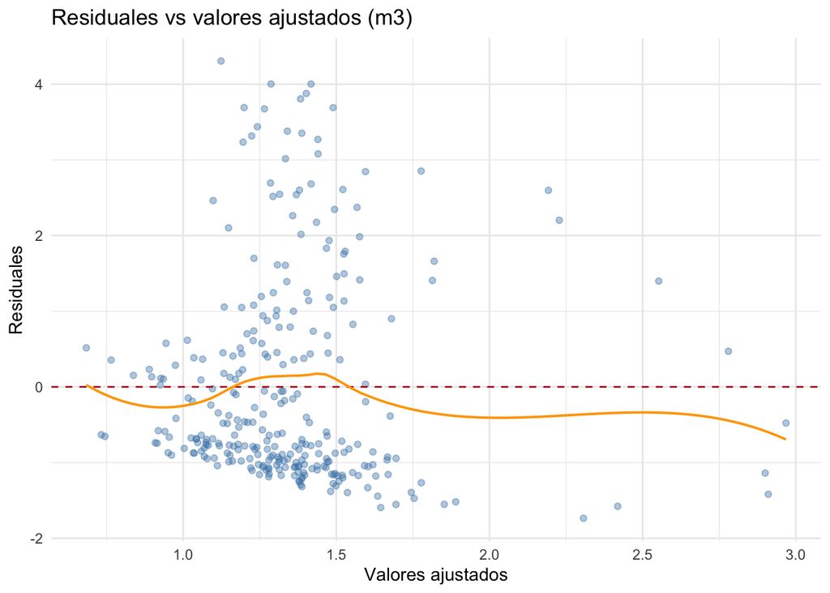

```r
augment(m3) %>%
  ggplot(aes(x = .fitted, y = .resid)) +
  geom_point(alpha = 0.4, color = "steelblue") +
  geom_hline(yintercept = 0, linetype = "dashed", color = "firebrick") +
  geom_smooth(se = FALSE, color = "orange", linewidth = 0.7) +
  labs(title = "Residuales vs valores ajustados (m3)",
       x = "Valores ajustados", y = "Residuales") +
  theme_minimal()
```

**Ejercicio 12.** Grafica los residuales de `m3` en el tiempo. Para hacerlo, necesitas agregar la columna `fecha` al resultado de `augment()`. Usa `drop_na()` antes de hacer `augment()` para evitar problemas con los rezagos.

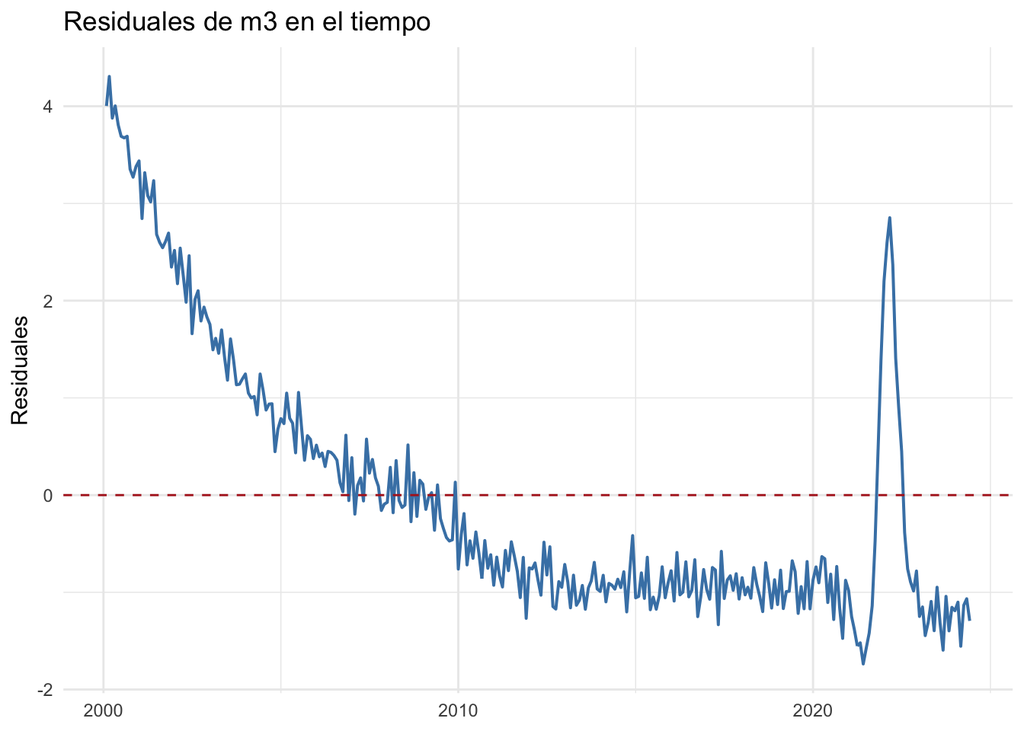

```r
macro_limpio <- macro %>% drop_na()
m3b <- lm(tasa_interes ~ desempleo + inflacion + tasa_lag1, data = macro_limpio)

augment(m3b, data = macro_limpio) %>%
  ggplot(aes(x = fecha, y = .resid)) +
  geom_line(color = "steelblue", linewidth = 0.7) +
  geom_hline(yintercept = 0, linetype = "dashed", color = "firebrick") +
  labs(title = "Residuales de m3 en el tiempo",
       x = NULL, y = "Residuales") +
  theme_minimal()
```

¿Los residuales muestran algún patrón persistente a lo largo del tiempo?

*Tu interpretación aquí.*

Sí. Los residuales se mueven en bloques que duran años en vez de oscilar alrededor de cero, hay autocorrelación. Esto tiene sentido ya que los grandes shocks macro duran años enteros, y el modelo lineal se equivoca en la misma dirección durante todo el régimen. La consecuencia es que los errores estándar y p-values del modelo no son confiables.

# Parte 6 — Período de crisis (opcional, para quien termine antes)

**Ejercicio 13.** Estima el mismo modelo `m3` pero usando solo las observaciones del período de crisis financiera (`crisis_financiera` del Ejercicio 3). Compara los coeficientes con los del modelo completo. ¿Cambia la relación durante la crisis?